# Optimal Treatment Analysis

## Outcome Variable

**Outcome Variable:** haz

## Predictor Variables

**Intervention Variable:** vagbrth

**Adjustment Set:**

- arm
- sex
- W_mage
- meducyrs
- feducyrs
- hhwealth_quart
- W_mhtcm
- W_mwtkg
- W_mbmi
- single
- W_nrooms
- brthmon
- W_parity
- impfloor
- delta_W_mage
- delta_meducyrs
- delta_feducyrs
- delta_hhwealth_quart
- delta_W_mhtcm
- delta_W_mwtkg
- delta_W_mbmi
- delta_single
- delta_W_nrooms
- delta_brthmon
- delta_W_parity
- delta_impfloor

## Stratifying Variables

The analysis was stratified on these variable(s):

- agecat
- studyid
- country

## Data Summary

| agecat | studyid | country | vagbrth | n_cell | n |
| --- | --- | --- | --- | --- | --- |
| Birth | CMC-V-BCS-2002 | INDIA | 0 | 11 | 92 |
| Birth | CMC-V-BCS-2002 | INDIA | 1 | 81 | 92 |
| Birth | IRC | INDIA | 0 | 68 | 388 |
| Birth | IRC | INDIA | 1 | 320 | 388 |
| Birth | JiVitA-3 | BANGLADESH | 0 | 539 | 22418 |
| Birth | JiVitA-3 | BANGLADESH | 1 | 21879 | 22418 |
| Birth | JiVitA-4 | BANGLADESH | 0 | 76 | 2822 |
| Birth | JiVitA-4 | BANGLADESH | 1 | 2746 | 2822 |
| Birth | NIH-Crypto | BANGLADESH | 0 | 186 | 477 |
| Birth | NIH-Crypto | BANGLADESH | 1 | 291 | 477 |
| Birth | PROBIT | BELARUS | 0 | 1597 | 13893 |
| Birth | PROBIT | BELARUS | 1 | 12296 | 13893 |
| Birth | PROVIDE | BANGLADESH | 0 | 108 | 539 |
| Birth | PROVIDE | BANGLADESH | 1 | 431 | 539 |
| Birth | ZVITAMBO | ZIMBABWE | 0 | 1166 | 13761 |
| Birth | ZVITAMBO | ZIMBABWE | 1 | 12595 | 13761 |
| 6 months | CMC-V-BCS-2002 | INDIA | 0 | 25 | 369 |
| 6 months | CMC-V-BCS-2002 | INDIA | 1 | 344 | 369 |
| 6 months | IRC | INDIA | 0 | 69 | 407 |
| 6 months | IRC | INDIA | 1 | 338 | 407 |
| 6 months | JiVitA-3 | BANGLADESH | 0 | 1077 | 16732 |
| 6 months | JiVitA-3 | BANGLADESH | 1 | 15655 | 16732 |
| 6 months | JiVitA-4 | BANGLADESH | 0 | 336 | 4052 |
| 6 months | JiVitA-4 | BANGLADESH | 1 | 3716 | 4052 |
| 6 months | NIH-Crypto | BANGLADESH | 0 | 187 | 457 |
| 6 months | NIH-Crypto | BANGLADESH | 1 | 270 | 457 |
| 6 months | PROBIT | BELARUS | 0 | 1799 | 15760 |
| 6 months | PROBIT | BELARUS | 1 | 13961 | 15760 |
| 6 months | PROVIDE | BANGLADESH | 0 | 139 | 604 |
| 6 months | PROVIDE | BANGLADESH | 1 | 465 | 604 |
| 6 months | TanzaniaChild2 | TANZANIA, UNITED REPUBLIC OF | 0 | 189 | 2005 |
| 6 months | TanzaniaChild2 | TANZANIA, UNITED REPUBLIC OF | 1 | 1816 | 2005 |
| 6 months | ZVITAMBO | ZIMBABWE | 0 | 740 | 8601 |
| 6 months | ZVITAMBO | ZIMBABWE | 1 | 7861 | 8601 |
| 24 months | CMC-V-BCS-2002 | INDIA | 0 | 24 | 371 |
| 24 months | CMC-V-BCS-2002 | INDIA | 1 | 347 | 371 |
| 24 months | IRC | INDIA | 0 | 69 | 409 |
| 24 months | IRC | INDIA | 1 | 340 | 409 |
| 24 months | JiVitA-3 | BANGLADESH | 0 | 480 | 8584 |
| 24 months | JiVitA-3 | BANGLADESH | 1 | 8104 | 8584 |
| 24 months | JiVitA-4 | BANGLADESH | 0 | 323 | 4020 |
| 24 months | JiVitA-4 | BANGLADESH | 1 | 3697 | 4020 |
| 24 months | NIH-Crypto | BANGLADESH | 0 | 99 | 260 |
| 24 months | NIH-Crypto | BANGLADESH | 1 | 161 | 260 |
| 24 months | PROBIT | BELARUS | 0 | 472 | 4035 |
| 24 months | PROBIT | BELARUS | 1 | 3563 | 4035 |
| 24 months | PROVIDE | BANGLADESH | 0 | 137 | 578 |
| 24 months | PROVIDE | BANGLADESH | 1 | 441 | 578 |
| 24 months | TanzaniaChild2 | TANZANIA, UNITED REPUBLIC OF | 0 | 2 | 6 |
| 24 months | TanzaniaChild2 | TANZANIA, UNITED REPUBLIC OF | 1 | 4 | 6 |
| 24 months | ZVITAMBO | ZIMBABWE | 0 | 133 | 1619 |
| 24 months | ZVITAMBO | ZIMBABWE | 1 | 1486 | 1619 |

The following strata were considered:

- agecat: 24 months, studyid: CMC-V-BCS-2002, country: INDIA
- agecat: 24 months, studyid: IRC, country: INDIA
- agecat: 24 months, studyid: JiVitA-3, country: BANGLADESH
- agecat: 24 months, studyid: JiVitA-4, country: BANGLADESH
- agecat: 24 months, studyid: NIH-Crypto, country: BANGLADESH
- agecat: 24 months, studyid: PROBIT, country: BELARUS
- agecat: 24 months, studyid: PROVIDE, country: BANGLADESH
- agecat: 24 months, studyid: TanzaniaChild2, country: TANZANIA, UNITED REPUBLIC OF
- agecat: 24 months, studyid: ZVITAMBO, country: ZIMBABWE
- agecat: 6 months, studyid: CMC-V-BCS-2002, country: INDIA
- agecat: 6 months, studyid: IRC, country: INDIA
- agecat: 6 months, studyid: JiVitA-3, country: BANGLADESH
- agecat: 6 months, studyid: JiVitA-4, country: BANGLADESH
- agecat: 6 months, studyid: NIH-Crypto, country: BANGLADESH
- agecat: 6 months, studyid: PROBIT, country: BELARUS
- agecat: 6 months, studyid: PROVIDE, country: BANGLADESH
- agecat: 6 months, studyid: TanzaniaChild2, country: TANZANIA, UNITED REPUBLIC OF
- agecat: 6 months, studyid: ZVITAMBO, country: ZIMBABWE
- agecat: Birth, studyid: CMC-V-BCS-2002, country: INDIA
- agecat: Birth, studyid: IRC, country: INDIA
- agecat: Birth, studyid: JiVitA-3, country: BANGLADESH
- agecat: Birth, studyid: JiVitA-4, country: BANGLADESH
- agecat: Birth, studyid: NIH-Crypto, country: BANGLADESH
- agecat: Birth, studyid: PROBIT, country: BELARUS
- agecat: Birth, studyid: PROVIDE, country: BANGLADESH
- agecat: Birth, studyid: ZVITAMBO, country: ZIMBABWE

### Dropped Strata

Some strata were dropped due to rare outcomes:

- agecat: 24 months, studyid: TanzaniaChild2, country: TANZANIA, UNITED REPUBLIC OF

## Methods Detail

We’re interested in the causal parameters $E[Y_a]$ for all values of $a \in \mathcal{A}$. These parameters represent the mean outcome if, possibly contrary to fact, we intervened to set all units to have $A=a$. Under the randomization and positivity assumptions, these are identified by the statistical parameters $\psi_a=E_W[E_{Y|A,W}(Y|A=a,W)]$. In addition, we’re interested in the mean of $Y$, $E[Y]$ under no intervention (the observed mean). We will estimate these parameters by using SuperLearner to fit the relevant likelihood factors – $E_{Y|A,W}(Y|A=a,W)$ and $p(A=a|W)$, and then updating our likelihood fit using a joint TMLE.

For unadjusted analyses ($W=\{\}$), initial likelihoods were estimated using Lrnr_glm to estimate the simple $E(Y|A)$ and Lrnr_mean to estimate $p(A)$. For adjusted analyses, a small library containing Lrnr_glmnet, Lrnr_xgboost, and Lrnr_mean was used.

Having estimated these parameters, we will then use the delta method to estimate relative risks and attributable risks relative to a prespecified baseline level of $A$.

# Results Detail

## Results Plots

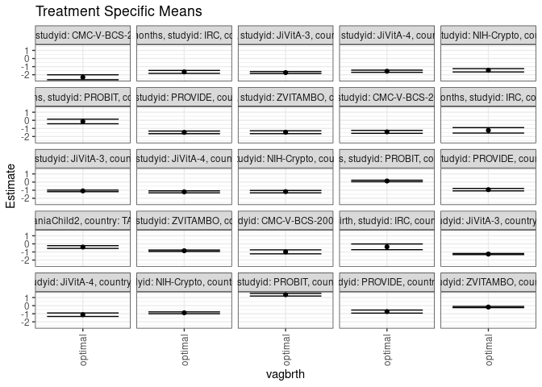

## Results Table

### Parameter: TSM

| agecat | studyid | country | intervention_level | baseline_level | estimate | ci_lower | ci_upper |
| --- | --- | --- | --- | --- | --- | --- | --- |
| Birth | CMC-V-BCS-2002 | INDIA | optimal | observed | -0.9847168 | -1.2292482 | -0.7401853 |
| Birth | IRC | INDIA | optimal | observed | -0.3661116 | -0.7194919 | -0.0127313 |
| Birth | JiVitA-3 | BANGLADESH | optimal | observed | -1.2599426 | -1.3256374 | -1.1942478 |
| Birth | JiVitA-4 | BANGLADESH | optimal | observed | -1.1184821 | -1.3339691 | -0.9029951 |
| Birth | NIH-Crypto | BANGLADESH | optimal | observed | -0.8820272 | -0.9951576 | -0.7688968 |
| Birth | PROBIT | BELARUS | optimal | observed | 1.3503386 | 1.1890675 | 1.5116098 |
| Birth | PROVIDE | BANGLADESH | optimal | observed | -0.7343271 | -0.9239815 | -0.5446728 |
| Birth | ZVITAMBO | ZIMBABWE | optimal | observed | -0.1747525 | -0.2474645 | -0.1020405 |
| 6 months | CMC-V-BCS-2002 | INDIA | optimal | observed | -1.4264971 | -1.6080250 | -1.2449692 |
| 6 months | IRC | INDIA | optimal | observed | -1.2423809 | -1.5774124 | -0.9073495 |
| 6 months | JiVitA-3 | BANGLADESH | optimal | observed | -1.0887643 | -1.1875964 | -0.9899322 |
| 6 months | JiVitA-4 | BANGLADESH | optimal | observed | -1.2056479 | -1.3270649 | -1.0842310 |
| 6 months | NIH-Crypto | BANGLADESH | optimal | observed | -1.1804447 | -1.3273207 | -1.0335688 |
| 6 months | PROBIT | BELARUS | optimal | observed | 0.1339018 | 0.0396664 | 0.2281372 |
| 6 months | PROVIDE | BANGLADESH | optimal | observed | -0.9352400 | -1.0872284 | -0.7832515 |
| 6 months | TanzaniaChild2 | TANZANIA, UNITED REPUBLIC OF | optimal | observed | -0.3922242 | -0.5614548 | -0.2229936 |
| 6 months | ZVITAMBO | ZIMBABWE | optimal | observed | -0.8491294 | -0.9358839 | -0.7623749 |
| 24 months | CMC-V-BCS-2002 | INDIA | optimal | observed | -2.3136200 | -2.6172145 | -2.0100255 |
| 24 months | IRC | INDIA | optimal | observed | -1.6564745 | -1.8381033 | -1.4748458 |
| 24 months | JiVitA-3 | BANGLADESH | optimal | observed | -1.7363947 | -1.8600390 | -1.6127504 |
| 24 months | JiVitA-4 | BANGLADESH | optimal | observed | -1.5710368 | -1.7058342 | -1.4362395 |
| 24 months | NIH-Crypto | BANGLADESH | optimal | observed | -1.4564292 | -1.6573505 | -1.2555079 |
| 24 months | PROBIT | BELARUS | optimal | observed | -0.1449851 | -0.4267224 | 0.1367521 |
| 24 months | PROVIDE | BANGLADESH | optimal | observed | -1.4904761 | -1.6529184 | -1.3280338 |
| 24 months | ZVITAMBO | ZIMBABWE | optimal | observed | -1.4717429 | -1.6470460 | -1.2964399 |

### Parameter: E(Y)

| agecat | studyid | country | intervention_level | baseline_level | estimate | ci_lower | ci_upper |
| --- | --- | --- | --- | --- | --- | --- | --- |
| Birth | CMC-V-BCS-2002 | INDIA | observed | observed | -0.9611957 | -1.1776967 | -0.7446946 |
| Birth | IRC | INDIA | observed | observed | -0.3080412 | -0.4687931 | -0.1472894 |
| Birth | JiVitA-3 | BANGLADESH | observed | observed | -1.5892417 | -1.6084834 | -1.5700000 |
| Birth | JiVitA-4 | BANGLADESH | observed | observed | -1.5231680 | -1.5722488 | -1.4740872 |
| Birth | NIH-Crypto | BANGLADESH | observed | observed | -0.9480084 | -1.0301396 | -0.8658772 |
| Birth | PROBIT | BELARUS | observed | observed | 1.3114417 | 1.1524752 | 1.4704082 |
| Birth | PROVIDE | BANGLADESH | observed | observed | -0.8851020 | -0.9601332 | -0.8100709 |
| Birth | ZVITAMBO | ZIMBABWE | observed | observed | -0.4970772 | -0.5177022 | -0.4764523 |
| 6 months | CMC-V-BCS-2002 | INDIA | observed | observed | -1.4234508 | -1.5645974 | -1.2823042 |
| 6 months | IRC | INDIA | observed | observed | -1.2344062 | -1.3658524 | -1.1029600 |
| 6 months | JiVitA-3 | BANGLADESH | observed | observed | -1.3134013 | -1.3366073 | -1.2901952 |
| 6 months | JiVitA-4 | BANGLADESH | observed | observed | -1.3500888 | -1.3921730 | -1.3080047 |
| 6 months | NIH-Crypto | BANGLADESH | observed | observed | -1.2731619 | -1.3626957 | -1.1836282 |
| 6 months | PROBIT | BELARUS | observed | observed | 0.0980074 | 0.0062724 | 0.1897424 |
| 6 months | PROVIDE | BANGLADESH | observed | observed | -1.0916915 | -1.1661176 | -1.0172654 |
| 6 months | TanzaniaChild2 | TANZANIA, UNITED REPUBLIC OF | observed | observed | -0.5455565 | -0.5948696 | -0.4962435 |
| 6 months | ZVITAMBO | ZIMBABWE | observed | observed | -0.8685914 | -0.8942954 | -0.8428875 |
| 24 months | CMC-V-BCS-2002 | INDIA | observed | observed | -2.5588679 | -2.6583730 | -2.4593629 |
| 24 months | IRC | INDIA | observed | observed | -1.7987775 | -1.8923914 | -1.7051636 |
| 24 months | JiVitA-3 | BANGLADESH | observed | observed | -2.0144245 | -2.0420946 | -1.9867544 |
| 24 months | JiVitA-4 | BANGLADESH | observed | observed | -1.7734527 | -1.8119258 | -1.7349797 |
| 24 months | NIH-Crypto | BANGLADESH | observed | observed | -1.5776538 | -1.6988448 | -1.4564629 |
| 24 months | PROBIT | BELARUS | observed | observed | -0.1442891 | -0.4253755 | 0.1367972 |
| 24 months | PROVIDE | BANGLADESH | observed | observed | -1.6024221 | -1.6857420 | -1.5191023 |
| 24 months | ZVITAMBO | ZIMBABWE | observed | observed | -1.6043391 | -1.6616652 | -1.5470130 |

### Parameter: PAR

| agecat | studyid | country | intervention_level | baseline_level | estimate | ci_lower | ci_upper |
| --- | --- | --- | --- | --- | --- | --- | --- |
| Birth | CMC-V-BCS-2002 | INDIA | optimal | observed | 0.0235211 | -0.0748962 | 0.1219385 |
| Birth | IRC | INDIA | optimal | observed | 0.0580704 | -0.2644793 | 0.3806201 |
| Birth | JiVitA-3 | BANGLADESH | optimal | observed | -0.3292991 | -0.3940873 | -0.2645109 |
| Birth | JiVitA-4 | BANGLADESH | optimal | observed | -0.4046858 | -0.6185048 | -0.1908668 |
| Birth | NIH-Crypto | BANGLADESH | optimal | observed | -0.0659812 | -0.1517960 | 0.0198337 |
| Birth | PROBIT | BELARUS | optimal | observed | -0.0388969 | -0.1141915 | 0.0363977 |
| Birth | PROVIDE | BANGLADESH | optimal | observed | -0.1507749 | -0.3198238 | 0.0182739 |
| Birth | ZVITAMBO | ZIMBABWE | optimal | observed | -0.3223247 | -0.3920702 | -0.2525792 |
| 6 months | CMC-V-BCS-2002 | INDIA | optimal | observed | 0.0030463 | -0.1704672 | 0.1765598 |
| 6 months | IRC | INDIA | optimal | observed | 0.0079747 | -0.2792998 | 0.2952492 |
| 6 months | JiVitA-3 | BANGLADESH | optimal | observed | -0.2246369 | -0.3206854 | -0.1285885 |
| 6 months | JiVitA-4 | BANGLADESH | optimal | observed | -0.1444409 | -0.2607966 | -0.0280852 |
| 6 months | NIH-Crypto | BANGLADESH | optimal | observed | -0.0927172 | -0.2063421 | 0.0209077 |
| 6 months | PROBIT | BELARUS | optimal | observed | -0.0358944 | -0.0799389 | 0.0081501 |
| 6 months | PROVIDE | BANGLADESH | optimal | observed | -0.1564515 | -0.2882745 | -0.0246286 |
| 6 months | TanzaniaChild2 | TANZANIA, UNITED REPUBLIC OF | optimal | observed | -0.1533323 | -0.3146429 | 0.0079782 |
| 6 months | ZVITAMBO | ZIMBABWE | optimal | observed | -0.0194620 | -0.1028439 | 0.0639198 |
| 24 months | CMC-V-BCS-2002 | INDIA | optimal | observed | -0.2452479 | -0.5365838 | 0.0460880 |
| 24 months | IRC | INDIA | optimal | observed | -0.1423030 | -0.3063866 | 0.0217807 |
| 24 months | JiVitA-3 | BANGLADESH | optimal | observed | -0.2780298 | -0.3971166 | -0.1589430 |
| 24 months | JiVitA-4 | BANGLADESH | optimal | observed | -0.2024159 | -0.3326446 | -0.0721873 |
| 24 months | NIH-Crypto | BANGLADESH | optimal | observed | -0.1212246 | -0.2843433 | 0.0418940 |
| 24 months | PROBIT | BELARUS | optimal | observed | 0.0006960 | -0.0785051 | 0.0798971 |
| 24 months | PROVIDE | BANGLADESH | optimal | observed | -0.1119460 | -0.2544043 | 0.0305122 |
| 24 months | ZVITAMBO | ZIMBABWE | optimal | observed | -0.1325962 | -0.3017105 | 0.0365182 |